# Reproducible Research - Assignment 1

sliechocki

2022-06-20

# Activity monitoring data

Evaluation of personal movement data obtained through activity monitoring devices between October and November 2012.

### Load database

The data is stored in a “csv” file. First of all, we needed to load the package we used to work on the data. After that, the code below will read the file and transform the “date” column in the proper date format:

```r
library(tidyverse) #Package: Tidyverse
actdata<-read.csv("activity.csv",sep = ",",header = T)
actdata$date<-as.Date(actdata$date) #Transforming "date" in a date format
```

### Total number of steps taken per day

The first analysis was to count the number of steps acquired per day during the period established. In the first part of the work, we do not considered the missing data.

```r
stepnumber<-actdata%>%
        group_by(date)%>%
        filter(steps!="NA")%>% #removes NA
        summarise(counts=sum(steps,na.rm = T))
head(stepnumber)
```

```
## # A tibble: 6 x 2
##   date       counts
##   <date>      <int>
## 1 2012-10-02    126
## 2 2012-10-03  11352
## 3 2012-10-04  12116
## 4 2012-10-05  13294
## 5 2012-10-06  15420
## 6 2012-10-07  11015
```

We used the histogram below to perform an exploratory analysis of the data:

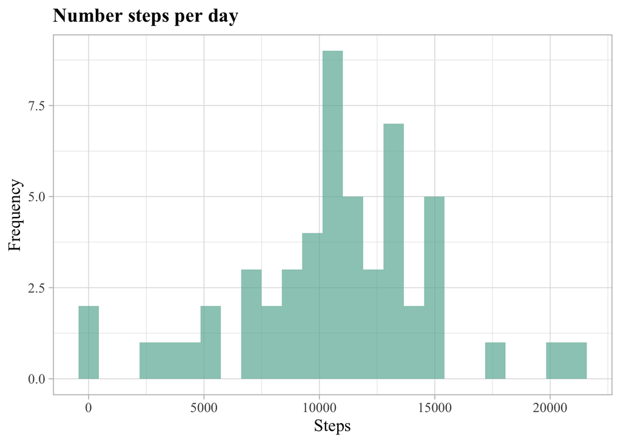

```r
ggplot(stepnumber, aes(counts))+
        geom_histogram(bins = 25,fill="#69b3a2", alpha=.7)+
        labs(title = "Number steps per day",
             y="Frequency", x="Steps")+
        theme_light(base_family = "Times New Roman",
                    base_size = 14)+
        theme(plot.title = element_text(face ="bold", size = 16))
```

Mean and median of the total number of steps taken per day

```r
steptable<-stepnumber%>%
        summarise(
                mean.steps=mean(counts, na.rm=T),
                median.steps=median(counts, na.rm = T))
steptable
```

```
## # A tibble: 1 x 2
##   mean.steps median.steps
##        <dbl>        <int>
## 1     10766.        10765
```

In order to obtain the average activity per day, the data was grouped based on the time interval (every five minutes) and after that the mean value of the steps was calculated.

```r
timeseries<-actdata%>%
        na.omit()%>%
        group_by(interval)%>%
        summarise(mean=mean(steps, na.rm=T))
head(timeseries)
```

```
## # A tibble: 6 x 2
##   interval   mean
##      <int>  <dbl>
## 1        0 1.72
## 2        5 0.340
## 3       10 0.132
## 4       15 0.151
## 5       20 0.0755
## 6       25 2.09
```

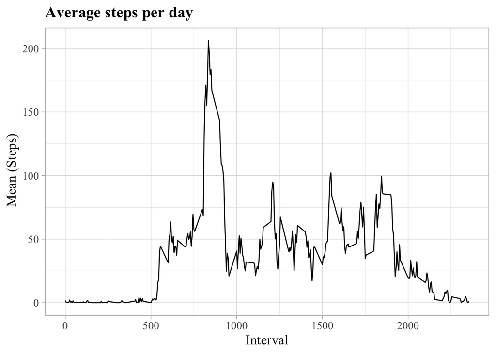

```r
ggplot(timeseries, aes(interval, mean))+
        geom_line()+
        labs(title = "Average steps per day",
             y=" Mean (Steps)", x="Interval")+
        theme_light(base_family = "Times New Roman",
                    base_size = 14)+
        theme(plot.title = element_text(face ="bold", size = 16))
```

With the “time series data” it was possible to know in which interval contains the highest number of steps:

```r
maximalnumber<-timeseries%>%
        filter(mean==max(mean))
print(maximalnumber)
```

```
## # A tibble: 1 x 2
##   interval  mean
##      <int> <dbl>
## 1      835  206.
```

### Impact of missing data (NA) on data analyis

First of all, we calculated the percentage of NA in the activity monitoring data:

```r
percentageNA<-mean(is.na(actdata))*100
format(round(percentageNA,2))
```

```
## [1] "4.37"
```

```r
fill<-actdata%>%
        filter(interval=="5")%>%
        summarise(mean=mean(steps, na.rm=T))%>%
        as.numeric()

#New data
newdata<-actdata%>%
        replace(is.na(.), format(round(fill,2)))
```

We repeat the procedure from the first part of the exercise, now using the new data. We group the data by date and calculate, the sum of the steps taken during that day. The result of this analysis was reported as the histogram below:

```r
h<-newdata%>%
        group_by(date)%>%
        summarise(
                counts=sum(as.numeric(steps),na.rm = T))
```

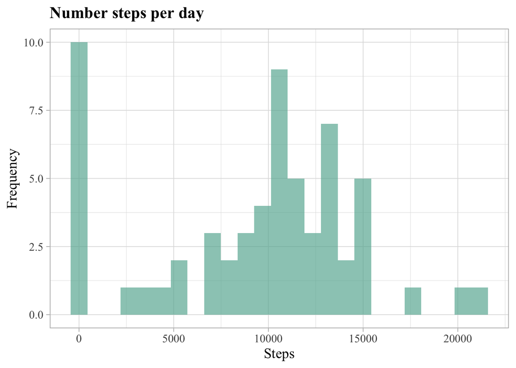

```r
ggplot(h, aes(counts))+
        geom_histogram(bins = 25,fill="#69b3a2", alpha=.7)+
        labs(title = "Number steps per day",
             y="Frequency", x="Steps")+
        theme_light(base_family = "Times New Roman",
                    base_size = 14)+
        theme(plot.title = element_text(face ="bold", size = 16))
```

We could then compared the mean/median of the data with NA and the new data:

```r
steptable2<-h%>%
        summarise(
                mean.steps=mean(counts, na.rm=T),
                median.steps=median(counts, na.rm = T))
```

By replacing the missing data, we observed a decrease in both measurements: Mean from 10766 to 9367 and the median from 10765 to 10395.

To check of there was changed in activity pattern between weekdays and weekend, we first added the day of the week for each day in a new column. Based on this new column, we applied a filter that contained or not contained “Saturday” and “Sunday” to generate two different data frames. After that, the two data frame were merged in one and the profile based on this label was verified by a time series plot.

```r
newdata$weekday<-weekdays(newdata$date)
weekends<-c("Saturday", "Sunday") # conditional filter

a<-newdata%>%filter(!weekday %in% weekends)%>%
        mutate(Day="weekday")
b<-newdata%>%
        filter(weekday %in% weekends)%>%
        mutate(Day="weekend")

newdata2<-rbind(a,b) # new data frame with weekday and weekend labels
newdata2$Day<-as.factor(newdata2$Day) #transforming in factor

## Daily activity based on weekdays
timeseries2<-newdata2%>%
        group_by(interval, Day)%>%
        mutate_at(vars(matches("steps")), as.numeric)%>%
        summarise(mean=mean(steps))
```

The result of daily activity based on weekdays can be observed in the time series plot below:

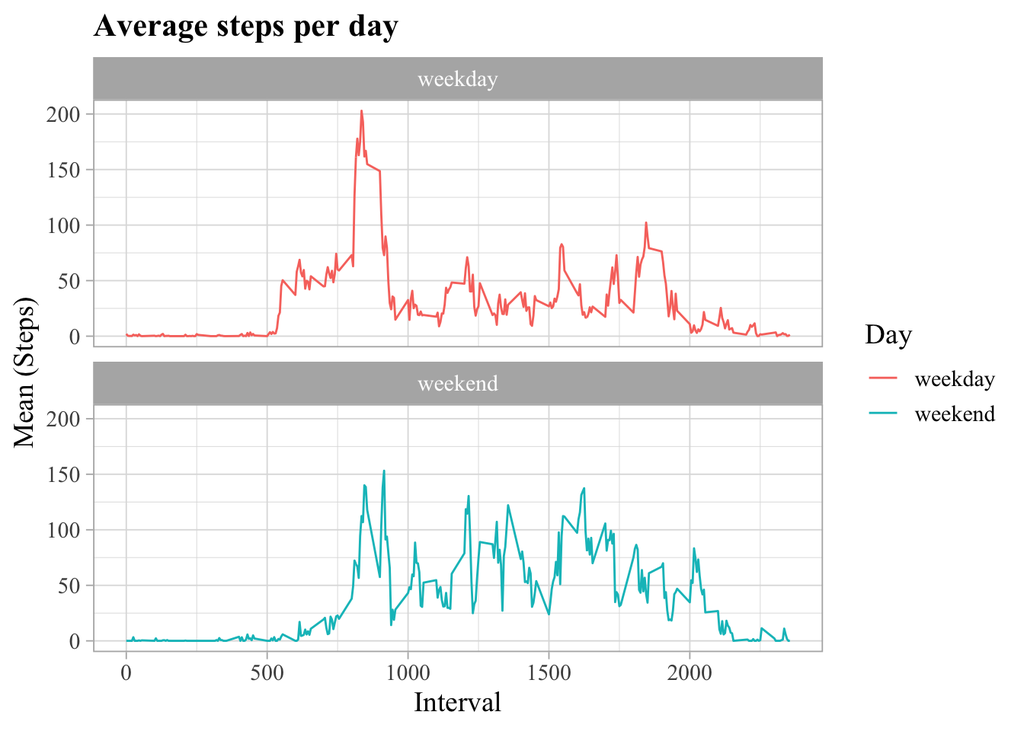

```r
ggplot(timeseries2, aes(interval, mean, color=Day))+
        geom_line()+
        labs(title = "Average steps per day",
             y=" Mean (Steps)", x="Interval")+
        theme_light(base_family = "Times New Roman",
                    base_size = 14)+
        theme(plot.title = element_text(face ="bold", size = 16))+
        facet_wrap(~Day,nrow = 2)
```

End of the assignment.